# The Daily Wire Coverage of Kamala Harris and Donald Trump

2024-12-07

# **Introduction**

In the following project, I have collected 198 articles from the Daily Wire, a prominent right-wing media organization in the United States. These articles are part of a larger research project aimed at analyzing how this outlet portrays two political figures: Kamala Harris and Donald Trump. The project focuses on articles published a few days before recent elections, as this period is likely to reveal editorial patterns and biases in politically charged reporting. My immediate goal is to expand the dataset to 99 articles about each candidate to ensure thorough comparative analysis. (Selecting 100 articles for Harris would cause the timeline change - that is why I only selected 99 articles from Oct. 14 to Nov. 4, just before the U.S. Presidential Elections.)

The core of this research lies in examining the language and sentiment employed by the Daily Wire when referring to Kamala Harris versus Donald Trump. I aim to identify patterns in tone, word choice, and framing. Sentiment analysis will help determine whether the portrayal of Harris skews more negative or positive compared to Trump, while textual comparisons will highlight recurring themes and rhetorical strategies.

Ultimately, this project seeks to analyze the frequency of biases in the Daily Wire’s reporting towards both Kamala Harris and Donald Trump. If disparities in sentiment and language are evident, it could provide valuable insights into the media outlet’s approach to covering candidates of opposing political affiliations. By shedding light on these patterns, the study will contribute to broader conversations about media bias and its influence on public opinion during critical electoral periods.

The decision to gather articles from the period between October 14 and November 4 reflects a critical phase in the lead-up to the U.S. presidential election. This timeframe includes the final weeks of the campaign, a period when media coverage intensifies, candidates make last-minute appeals to voters, and public discourse often reaches its peak. By focusing on this window, the analysis aims to capture the most concentrated and potentially impactful reporting, narratives, and biases leading up to one of the most consequential events in U.S. politics. This approach ensures the data reflects the media’s framing and emphasis during the election’s pivotal closing days.

The link to the Daily Wire Kamala Harris dataset: https://github.com/ninimtch93/CompText_Jour/blob/main/FPD_Nini/DW_Kamala_Articles.xlsx

# **Content Analysis Plan**

## **Building and Using My Code Book**

Throughout our classes, I have managed to start collecting all of the codes that we went through. Because my project is going to be a comparative analysis of how a right-wing media organization portraied a Republican and a Democrat presidential candidates, using the codes in a right order will hold a crucial role in my research.

After gathering all of the data, I will analyze the bigrams to compare what two-word phrases were mostly used while talking about Donald Trump and Kamala Harris.

For sentiment analysis, the codes will categorize text into: Positive: words like “success,” “strong,” or “leader.” Negative: words like “failure,” “weak,” or “untrustworthy.” Neutral or mixed: words like “controversial,” “debate,” or “discussion.”

I plan to apply consistent rules for identifying patterns in the articles and assign sentiment scores to compare how each candidate is portrayed.

##Analyzing the Data The analysis will include Text Analysis that will help me in identifying the most frequently used bigrams for each candidate and comparing the themes, and Sentiment Analysis that will allow me to measure the tone (positive, negative, or neutral) toward Kamala Harris and Donald Trump using sentiment lexicons.

## **Visualization with ggplot2**

I will aslo use a Word Cloud: Summarizing frequently used words or phrases visually.

### Standardizing Research

My code book will ensure consistency and transparency in coding the data. By defining clear rules for bigrams and sentiment categories, I will apply the same approach to all articles on both sides. This prevents subjective interpretations and makes it easier to compare language and tone across articles about Kamala Harris and Donald Trump.

### Organizing Data

With a large dataset of up to 200 articles, my code book will save time by providing a structured guide for categorizing and analyzing text. Having clear codes for key themes and sentiment ensures the focus remains on relevant patterns, leading to richer and more meaningful results.

### Quality Control

My code book will provide clear definitions and examples for each code, ensuring that data is entered and analyzed consistently. This systematic approach will reduce errors and strengthen the reliability of the findings. This will make it easier to draw valid conclusions about potential biases in the Daily Wire’s reporting.

# Initial Findings in the Daily Wire articles about Kamala Harris

To further explore the content, I analyzed bigrams—two-word phrases frequently used in the articles. The results supported the earlier observation: the articles did not delve deeply into substantive topics but instead emphasized general narratives or talking points. This pattern reflects a focus on quick, high-level coverage rather than comprehensive exploration of Harris’s policies or positions.

In addition to bigrams, I included a word cloud to examine the most frequently mentioned unigrams (single words). One interesting finding was the frequent appearance of “Trump” in articles about Kamala Harris. While “Harris” was mentioned 828 times, “Trump” appeared around 400 times—approximately half as often. To refine the analysis, if I deliberately exclude the terms “Kamala” and “Harris” from the unigrams, as their frequent occurrence is expected, the prominence of “Trump” suggests that The Daily Wire strategically framed its coverage of Harris in a way that often referenced or compared her to Trump. This framing highlights a potential focus on positioning Harris within a broader political context rather than solely evaluating her as an individual candidate. These findings will later be compared to those from the analysis of articles about Donald Trump.

```r
#Code for providing minimum, maximum, average, and median

summary_stats_kh <- data.frame(
  Min = min(WC_KH$WordCount, na.rm = TRUE),
  Max = max(WC_KH$WordCount, na.rm = TRUE),
  Mean = mean(WC_KH$WordCount, na.rm = TRUE),
  Median = median(WC_KH$WordCount, na.rm = TRUE)
)

summary_stats_kh
```

```
##   Min  Max     Mean Median
## 1 339 2655 715.7374    571
```

Visual graph of the word count in Daily Wire articles about Kamala Harris.

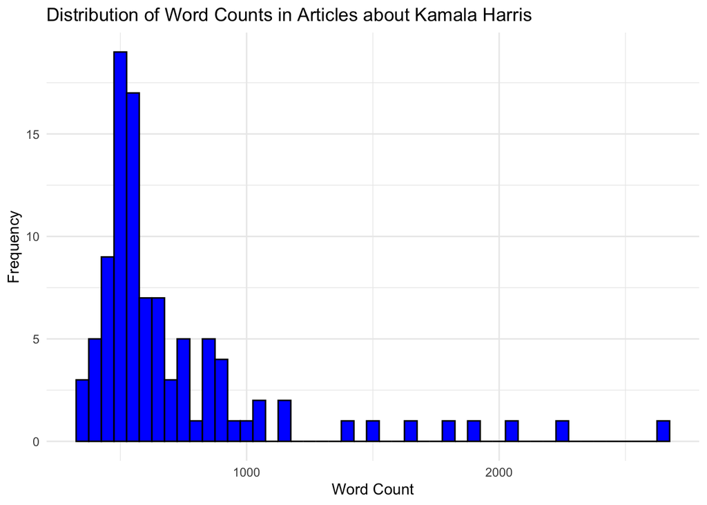

```r
#ggplot code for the word count visualization

ggplot(WC_KH, aes(x = WordCount)) +
  geom_histogram(binwidth = 50, fill = "blue", color = "black") +
  labs(
    title = "Distribution of Word Counts in Articles about Kamala Harris",
    x = "Word Count",
    y = "Frequency"
  ) +
  theme_minimal()
```

Code for counting rows

```r
#code for counting rows

nrow(harris_dw)
```

```
## [1] 99
```

Code for counting columns

```r
#code for counting columns

ncol(harris_dw)
```

```
## [1] 6
```

Vizualization of article-distiribution about Kamala Harris in the period of Oct. 14 to Nov. 4.

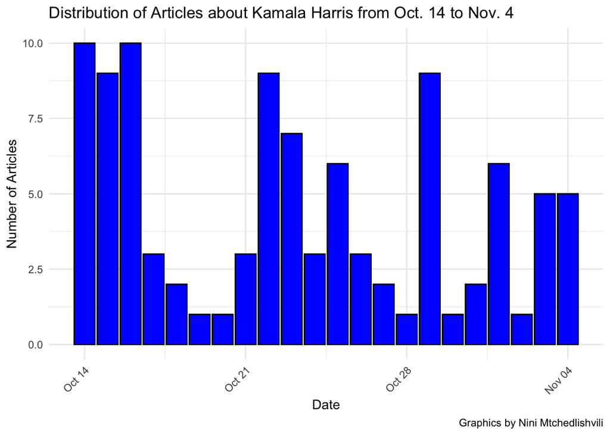

```r
#ggplot code for article timeline visualization

ggplot(harris_dw, aes(x = date1)) +
  geom_bar(binwidth = 7, fill = "blue", color = "black") +
  labs(
    title = "Distribution of Articles about Kamala Harris from Oct. 14 to Nov. 4",
    caption = "Graphics by Nini Mtchedlishvili",
    x = "Date",
    y = "Number of Articles"
  ) +
  theme_minimal() +
  theme(axis.text.x = element_text(angle = 45, hjust = 1))
```

Vizualization of Top 30 Bigrams

```r
#code for top 30 bigram visualization

kamala_top_30_bigrams <- kamala_bigrams_df %>%
  head(30)

kamala_top_30_bigrams
```

```
## # A tibble: 30 × 2
##    bigram               n
##    <chr>            <int>
##  1 kamala harris      239
##  2 vice president     111
##  3 donald trump       100
##  4 difference stay     99
##  5 president kamala    84
##  6 biden harris        60
##  7 harris campaign     55
##  8 matt walsh’s        54
##  9 joe biden           51
## 10 president donald    50
## # ℹ 20 more rows
```

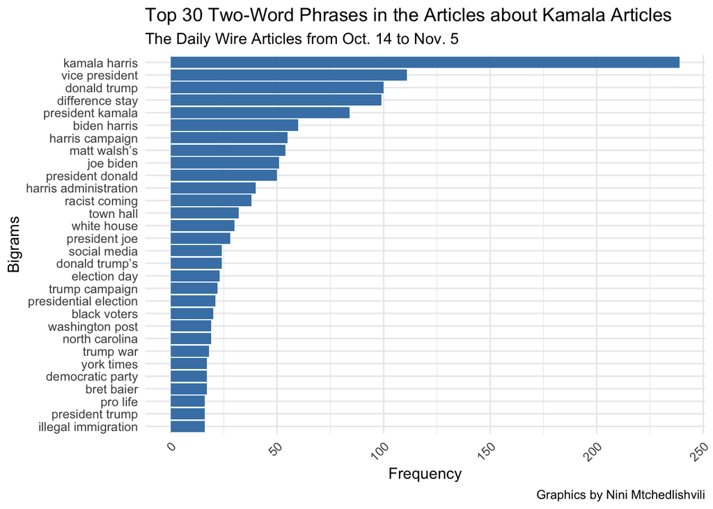

```r
#ggplot code for bigram count vizualization

ggplot(kamala_top_30_bigrams, aes(x = reorder(bigram, n), y = n)) +
  geom_bar(stat = "identity", fill = "steelblue") +
  labs(
    title = "Top 30 Two-Word Phrases in the Articles about Kamala Articles",
    subtitle = "The Daily Wire Articles from Oct. 14 to Nov. 5",
    caption = "Graphics by Nini Mtchedlishvili",
    x = "Bigrams",
    y = "Frequency"
  ) +
  theme_minimal() +
  theme(axis.text.x = element_text(angle = 45, hjust = 1)) +
  coord_flip()
```

```r
#code for top 30 unigrams

kamala_top_30_unigrams <- kamala_unigrams_df %>%
  arrange(desc(n)) %>%
  head(30)


kamala_top_30_unigrams
```

```
## # A tibble: 30 × 2
##    word          n
##    <chr>     <int>
##  1 harris      828
##  2 trump       385
##  3 kamala      326
##  4 president   303
##  5 campaign    202
##  6 biden       185
##  7 election    148
##  8 black       142
##  9 people      141
## 10 donald      129
## # ℹ 20 more rows
```

```r
#code for word cloud

wordcloud2(data = kamala_top_30_unigrams,
           size = 1,
           shape = 'circle',
           color = 'random-dark',
           backgroundColor = "white")
```

[interactive chart not shown]

# Initial findings in the articles about Donald Trump

I applied the same approach to analyzing The Daily Wire articles about Donald Trump. The word count for these articles ranged from 334 to 4,508 words, with most falling between 400 and 900 words. The minimum word count was 334, the maximum was 4,508, the average was 839 words, and the median was 558 words. This indicates that articles about Trump were generally longer than those about Kamala Harris, with approximately twice as many long-form pieces written about Trump during the analyzed period of October 14 to November 4. These longer articles provided more space for the media organization to craft a detailed narrative around Trump.

As with Harris, the bigram analysis revealed that most of the two-word phrases did not convey significant new information. This suggests that much of the content in these articles focused on creating a steady stream of coverage rather than providing in-depth analysis. While the content about Trump allowed for more extended discussions, the lack of substance in the bigrams indicates a continuation of the broader trend of generating “noise” rather than meaningful insights.

```r
#code for creating a word count dataframe

WC_DT <- trump_dw %>%
  select(article_text) %>%
  mutate(WordCount = str_count(article_text, "\\w+")) %>%
  arrange(desc(WordCount))
```

```r
#code for calculating minimum, maximum, average, and median word count in the articles

summary_stats_dt <- data.frame(
  Min = min(WC_DT$WordCount, na.rm = TRUE),
  Max = max(WC_DT$WordCount, na.rm = TRUE),
  Mean = mean(WC_DT$WordCount, na.rm = TRUE),
  Median = median(WC_DT$WordCount, na.rm = TRUE)
)

summary_stats_dt
```

```
##   Min  Max     Mean Median
## 1 334 4508 839.1515    558
```

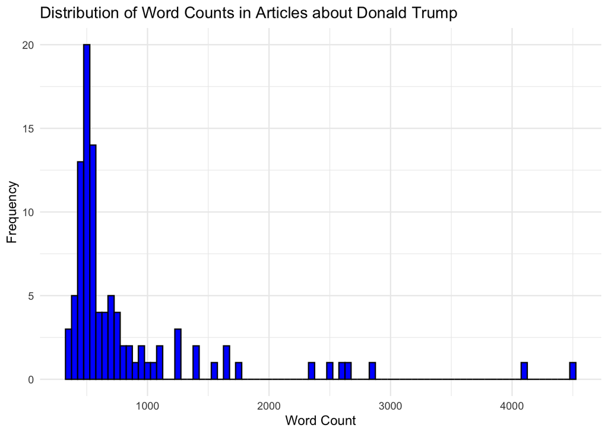

```r
#ggplot code for word count visualization

ggplot(WC_DT, aes(x = WordCount)) +
  geom_histogram(binwidth = 50, fill = "blue", color = "black") +
  labs(
    title = "Distribution of Word Counts in Articles about Donald Trump",
    x = "Word Count",
    y = "Frequency"
  ) +
  theme_minimal()
```

```r
#code for counting rows

nrow(trump_dw)
```

```
## [1] 99
```

```r
#code for counting columns

ncol(trump_dw)
```

```
## [1] 6
```

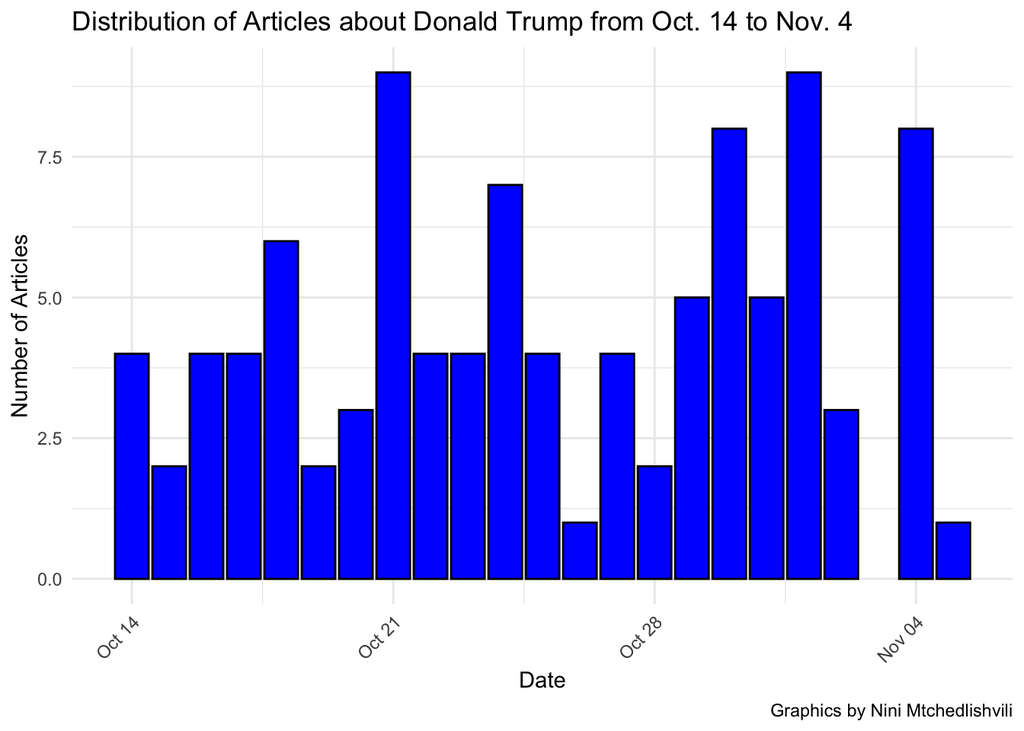

```r
#code for timeline visualization

ggplot(trump_dw, aes(x = date1)) +
  geom_bar(binwidth = 7, fill = "blue", color = "black") +
  labs(
    title = "Distribution of Articles about Donald Trump from Oct. 14 to Nov. 4",
    caption = "Graphics by Nini Mtchedlishvili",
    x = "Date",
    y = "Number of Articles"
  ) +
  theme_minimal() +
  theme(axis.text.x = element_text(angle = 45, hjust = 1))
```

The analysis below show bigrams/two-word phrases used in the articles regarding Donald Trump.

```r
#code for top 30 bigram

trump_top_30_bigrams <- trump_bigrams_df %>%
  head(30)

trump_top_30_bigrams
```

```
## # A tibble: 30 × 2
##    bigram               n
##    <chr>            <int>
##  1 donald trump       198
##  2 kamala harris      184
##  3 difference stay     99
##  4 president donald    88
##  5 vice president      86
##  6 president trump     66
##  7 election day        62
##  8 matt walsh’s        58
##  9 president kamala    58
## 10 north carolina      53
## # ℹ 20 more rows
```

[figure not shown]

```r
#ggplot code for bigram vizualization

ggplot(trump_top_30_bigrams, aes(x = reorder(bigram, n), y = n)) +
  geom_bar(stat = "identity", fill = "steelblue") +
  labs(
    title = "Top 30 Two-Word Phrases in the Articles about Kamala Articles",
    subtitle = "The Daily Wire Articles from Oct. 14 to Nov. 5",
    caption = "Graphics by Nini Mtchedlishvili",
    x = "Bigrams",
    y = "Frequency"
  ) +
  theme_minimal() +
  theme(axis.text.x = element_text(angle = 45, hjust = 1)) +
  coord_flip()
```

```r
#code for creating unigram dataframe

trump_unigrams_df <- trump_dw %>%
  unnest_tokens(word, article_text) %>%
  mutate(word=str_squish(word)) %>%
  mutate(word = gsub("[[:punct:]]", "", word)) %>%
  filter(
    !word %in% stop_words$word,
    !word %in% c("its","\\b[Ii][tT]’?s\\b", "i'm", "that’s", "they're", "don't", "2024",
                 "date", "latestnews", "latest", "news", "tip", "submit",
                 "missing", "its", "it", "is", "pic.twitter.com", "headline", "podcasts", "account", "shes", "'", "s", "oct", "text", "october", "story", "interview","article","dont", "pictwittercom", "theyre", "hes", "told", "stay", "time", "day", "piece", ""),
    !is.na(word)
  ) %>%
  count(word, sort = TRUE)

trump_unigrams_df
```

```
## # A tibble: 7,228 × 2
##    word          n
##    <chr>     <int>
##  1 trump      1165
##  2 harris      537
##  3 president   410
##  4 election    251
##  5 kamala      241
##  6 donald      226
##  7 people      216
##  8 campaign    204
##  9 biden       163
## 10 voters      144
## # ℹ 7,218 more rows
```

```r
#code for top 30 unigram

trump_top_30_unigrams <- trump_unigrams_df %>%
  arrange(desc(n)) %>%
  head(30)


trump_top_30_unigrams
```

```
## # A tibble: 30 × 2
##    word          n
##    <chr>     <int>
##  1 trump      1165
##  2 harris      537
##  3 president   410
##  4 election    251
##  5 kamala      241
##  6 donald      226
##  7 people      216
##  8 campaign    204
##  9 biden       163
## 10 voters      144
## # ℹ 20 more rows
```

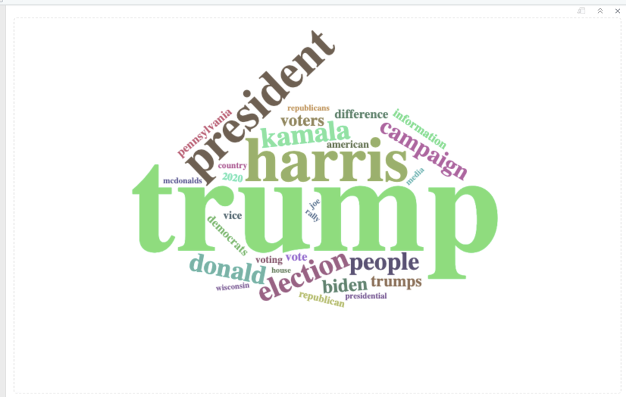

```r
#because the wordcloud does not appear on html website, this is the code for importing png file.

knitr::include_graphics("trump_wc.png")
```

# Comparative Sentiment analysis of the articles about Kamala Harris and Donald Trump

### Overall Sentiment analysis - Comparison

The sentiment analysis of Daily Wire articles about Kamala Harris and Donald Trump shows some clear differences in how each is portrayed. For Kamala Harris, the articles have a mix of positive (22%) and trust (15%) sentiments, but there’s also a strong presence of negative emotions like fear (9%), anger (8%), and disgust (5%). This suggests that while some positive aspects of Harris are recognized, they are often overshadowed by criticism and negative framing.

```r
kh_sentiments_all <- kh_text_tokenized %>%
  inner_join(kh_nrc_sentiments) %>%
  count(sentiment, sort = TRUE) %>%
  mutate(pct_total =round(n/sum(n), digits=2))
kh_sentiments_all
```

```
## # A tibble: 10 × 3
##    sentiment        n pct_total
##    <chr>        <int>     <dbl>
##  1 positive      3265      0.22
##  2 trust         2325      0.15
##  3 negative      2244      0.15
##  4 anticipation  1391      0.09
##  5 fear          1337      0.09
##  6 anger         1136      0.08
##  7 sadness        966      0.06
##  8 surprise       894      0.06
##  9 joy            794      0.05
## 10 disgust        709      0.05
```

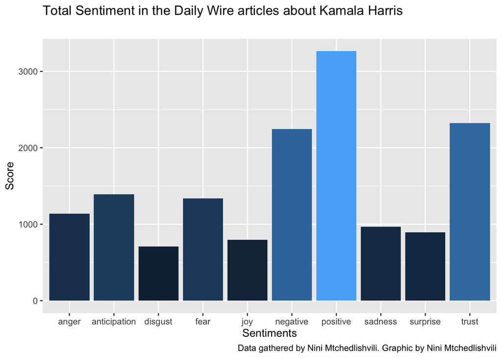

```r
kh_afinn_plot <- kh_sentiments_all %>%
  ggplot(aes(x = sentiment, y = n,fill = n)) +
  geom_col(position = "dodge") +
  theme(legend.position = "none") +
  labs(title = "Total Sentiment in the Daily Wire articles about Kamala Harris",
       subtitle = " ",
       caption = "Data gathered by Nini Mtchedlishvili. Graphic by Nini Mtchedlishvili",
       y="Score",
       x="Sentiments")

kh_afinn_plot
```

```r
dt_sentiments_all <- dt_text_tokenized %>%
  inner_join(dt_nrc_sentiments, by = join_by(word), relationship = "many-to-many") %>%
  count(sentiment, sort = TRUE) %>%
  mutate(pct_total =round(n/sum(n), digits=2))

dt_sentiments_all
```

```
## # A tibble: 10 × 3
##    sentiment        n pct_total
##    <chr>        <int>     <dbl>
##  1 positive      3557      0.2
##  2 trust         2714      0.15
##  3 negative      2572      0.14
##  4 surprise      1730      0.1
##  5 anticipation  1566      0.09
##  6 fear          1536      0.09
##  7 anger         1307      0.07
##  8 sadness       1158      0.07
##  9 joy            922      0.05
## 10 disgust        749      0.04
```

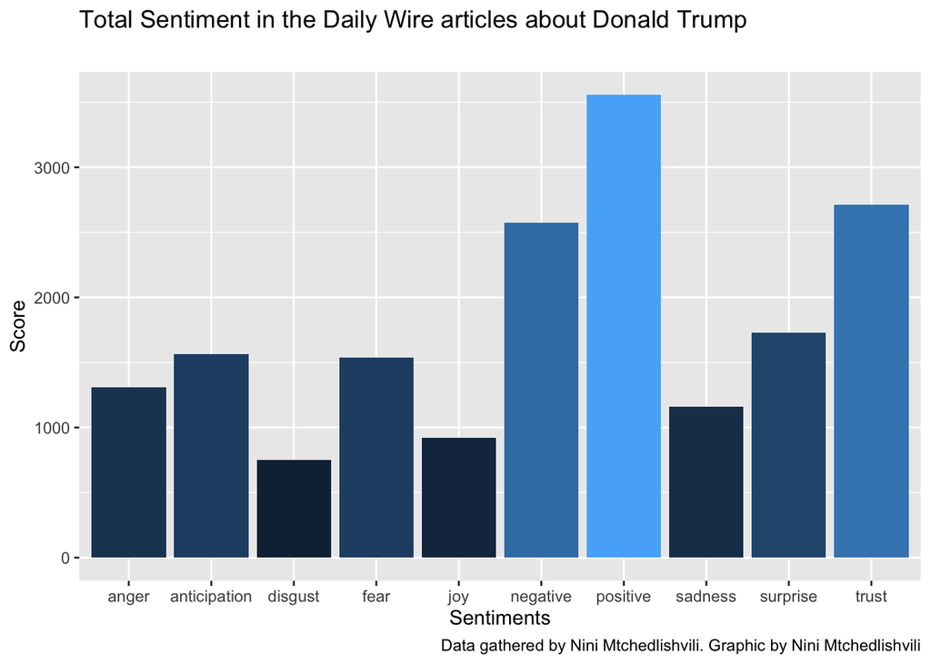

```r
dt_afinn_plot <- dt_sentiments_all %>%
  ggplot(aes(x = sentiment, y = n,fill = n)) +
  geom_col(position = "dodge") +
  theme(legend.position = "none") +
  labs(title = "Total Sentiment in the Daily Wire articles about Donald Trump",
       subtitle = " ",
       caption = "Data gathered by Nini Mtchedlishvili. Graphic by Nini Mtchedlishvili",
       y="Score",
       x="Sentiments")

dt_afinn_plot
```

# Comparative Sentiment Analysis of Anger, Anticipation, Fear, and Disgust Sentiments

### Anger Sentiment

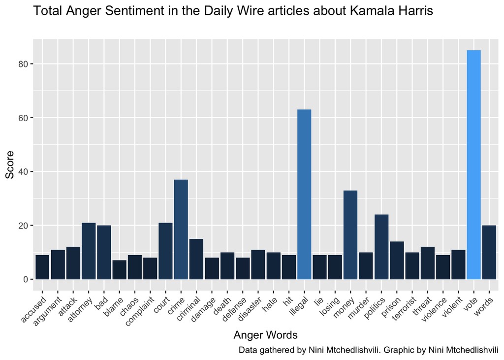

```r
kh_anger_plot <- kh_t30_anger %>%
  ggplot(aes(x = word, y = n, fill = n)) +
  geom_col(position = "dodge") +
  theme(legend.position = "none",
        axis.text.x = element_text(angle = 45, hjust = 1)) +
  labs(title = "Total Anger Sentiment in the Daily Wire articles about Kamala Harris",
       subtitle = " ",
       caption = "Data gathered by Nini Mtchedlishvili. Graphic by Nini Mtchedlishvili",
       y="Score",
       x="Anger Words")

kh_anger_plot
```

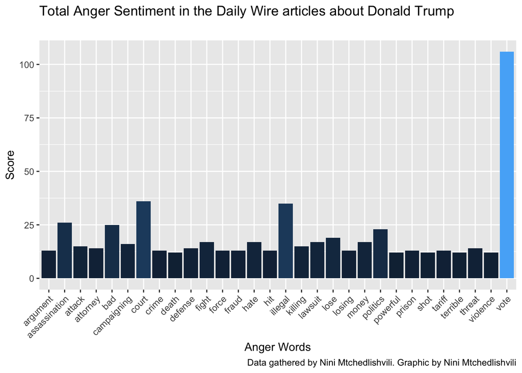

```r
dt_anger_plot <- dt_t30_anger %>%
  ggplot(aes(x = word, y = n, fill = n)) +
  geom_col(position = "dodge") +
  theme(legend.position = "none",
        axis.text.x = element_text(angle = 45, hjust = 1)) +
  labs(title = "Total Anger Sentiment in the Daily Wire articles about Donald Trump",
       subtitle = " ",
       caption = "Data gathered by Nini Mtchedlishvili. Graphic by Nini Mtchedlishvili",
       y="Score",
       x="Anger Words")

dt_anger_plot
```

### Anticipation Sentiment

**The anticipation sentiment for Kamala Harris** highlights words like **“victory,” “vote,” and “time,”** indicating an emphasis on electoral outcomes and timelines. This reflects an attempt to frame her actions or campaigns with a forward-looking perspective, though with less depth in substantive policy.

```r
kh_nrc_anticipation <- kh_nrc_sentiments %>%
  filter(sentiment == "anticipation")

kh_anticipation <- kh_text_tokenized%>%
  inner_join(kh_nrc_anticipation) %>%
  count(word, sort = TRUE)
kh_t30_anticipation <- kh_anticipation %>%
  head(30)

kh_t30_anticipation
```

```
## # A tibble: 30 × 2
##    word       n
##    <chr>  <int>
##  1 submit   100
##  2 time      93
##  3 vote      85
##  4 daily     53
##  5 coming    52
##  6 watch     51
##  7 money     33
##  8 top       29
##  9 public    28
## 10 ballot    27
## # ℹ 20 more rows
```

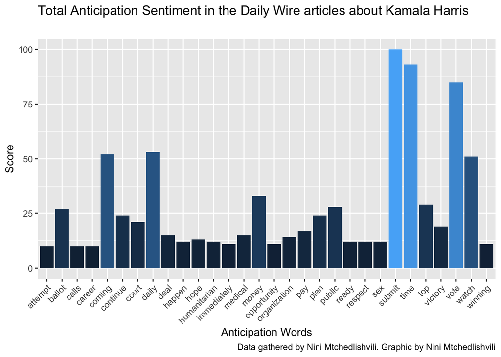

```r
kh_anticipation_plot <- kh_t30_anticipation %>%
  ggplot(aes(x = word, y = n, fill = n)) +
  geom_col(position = "dodge") +
  theme(legend.position = "none",
        axis.text.x = element_text(angle = 45, hjust = 1)) +
  labs(title = "Total Anticipation Sentiment in the Daily Wire articles about Kamala Harris",
       subtitle = " ",
       caption = "Data gathered by Nini Mtchedlishvili. Graphic by Nini Mtchedlishvili",
       y="Score",
       x="Anticipation Words")

kh_anticipation_plot
```

```r
dt_nrc_anticipation <- dt_nrc_sentiments %>%
  filter(sentiment == "anticipation")

dt_anticipation <- dt_text_tokenized%>%
  inner_join(dt_nrc_anticipation) %>%
  count(word, sort = TRUE)
dt_t30_anticipation <- dt_anticipation %>%
  head(30)

dt_t30_anticipation
```

```
## # A tibble: 30 × 2
##    word        n
##    <chr>   <int>
##  1 time      124
##  2 vote      106
##  3 submit    101
##  4 watch      59
##  5 coming     54
##  6 daily      52
##  7 court      36
##  8 top        32
##  9 ballot     31
## 10 attempt    25
## # ℹ 20 more rows
```

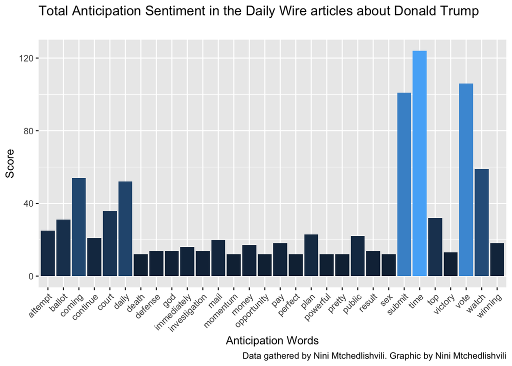

```r
dt_anticipation_plot <- dt_t30_anticipation %>%
  ggplot(aes(x = word, y = n, fill = n)) +
  geom_col(position = "dodge") +
  theme(legend.position = "none",
        axis.text.x = element_text(angle = 45, hjust = 1)) +
  labs(title = "Total Anticipation Sentiment in the Daily Wire articles about Donald Trump",
       subtitle = " ",
       caption = "Data gathered by Nini Mtchedlishvili. Graphic by Nini Mtchedlishvili",
       y="Score",
       x="Anticipation Words")

dt_anticipation_plot
```

### Fear Sentiment

**For Kamala Harris,** fear-associated terms like **“abortion,” “illegal,” “government,” and “war”** stand out prominently. Words such as “abortion” and “illegal” are consistently emphasized, suggesting the articles might associate her policies or actions with controversial or divisive topics.

```r
kh_nrc_fear <- kh_nrc_sentiments %>%
  filter(sentiment == "fear")

kh_fear <- kh_text_tokenized%>%
  inner_join(kh_nrc_fear) %>%
  count(word, sort = TRUE)
kh_t30_fear <- kh_fear %>%
  head(30)

kh_t30_fear
```

```
## # A tibble: 30 × 2
##    word           n
##    <chr>      <int>
##  1 illegal       63
##  2 abortion      52
##  3 watch         51
##  4 war           50
##  5 government    38
##  6 military      23
##  7 attorney      21
##  8 court         21
##  9 bad           20
## 10 change        20
## # ℹ 20 more rows
```

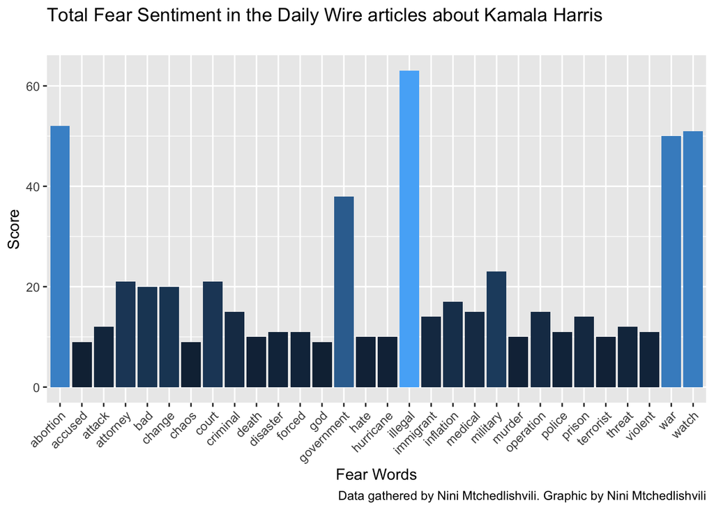

```r
kh_fear_plot <- kh_t30_fear %>%
  ggplot(aes(x = word, y = n, fill = n)) +
  geom_col(position = "dodge") +
  theme(legend.position = "none",
        axis.text.x = element_text(angle = 45, hjust = 1)) +
  labs(title = "Total Fear Sentiment in the Daily Wire articles about Kamala Harris",
       subtitle = " ",
       caption = "Data gathered by Nini Mtchedlishvili. Graphic by Nini Mtchedlishvili",
       y="Score",
       x="Fear Words")

kh_fear_plot
```

```r
dt_nrc_fear <- dt_nrc_sentiments %>%
  filter(sentiment == "fear")

dt_fear <- dt_text_tokenized%>%
  inner_join(dt_nrc_fear) %>%
  count(word, sort = TRUE)
dt_t30_fear <- dt_fear %>%
  head(30)

dt_t30_fear
```

```
## # A tibble: 30 × 2
##    word              n
##    <chr>         <int>
##  1 watch            59
##  2 war              54
##  3 abortion         53
##  4 court            36
##  5 government       36
##  6 illegal          35
##  7 inflation        30
##  8 assassination    26
##  9 bad              25
## 10 lose             19
## # ℹ 20 more rows
```

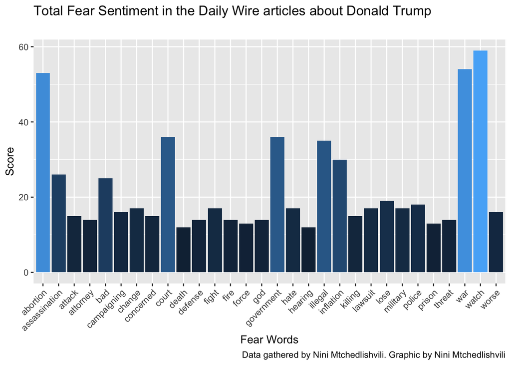

```r
dt_fear_plot <- dt_t30_fear %>%
  ggplot(aes(x = word, y = n, fill = n)) +
  geom_col(position = "dodge") +
  theme(legend.position = "none",
        axis.text.x = element_text(angle = 45, hjust = 1)) +
  labs(title = "Total Fear Sentiment in the Daily Wire articles about Donald Trump",
       subtitle = " ",
       caption = "Data gathered by Nini Mtchedlishvili. Graphic by Nini Mtchedlishvili",
       y="Score",
       x="Fear Words")

dt_fear_plot
```

### Disgust Sentiment

**In Kamala Harris’** case, disgust is tied to words like **“illegal,” “murder,” and “plagiarism,”** reflecting an effort to portray her in a morally negative light. There’s a clear focus on framing her actions as harmful or ethically questionable.

```r
kh_nrc_disgust <- kh_nrc_sentiments %>%
  filter(sentiment == "disgust")

kh_disgust <- kh_text_tokenized%>%
  inner_join(kh_nrc_disgust) %>%
  count(word, sort = TRUE)
kh_t30_disgust <- kh_disgust %>%
  head(30)

kh_t30_disgust
```

```
## # A tibble: 30 × 2
##    word           n
##    <chr>      <int>
##  1 illegal       63
##  2 abortion      52
##  3 plagiarism    39
##  4 bad           20
##  5 john          20
##  6 criminal      15
##  7 disaster      11
##  8 violent       11
##  9 winning       11
## 10 death         10
## # ℹ 20 more rows
```

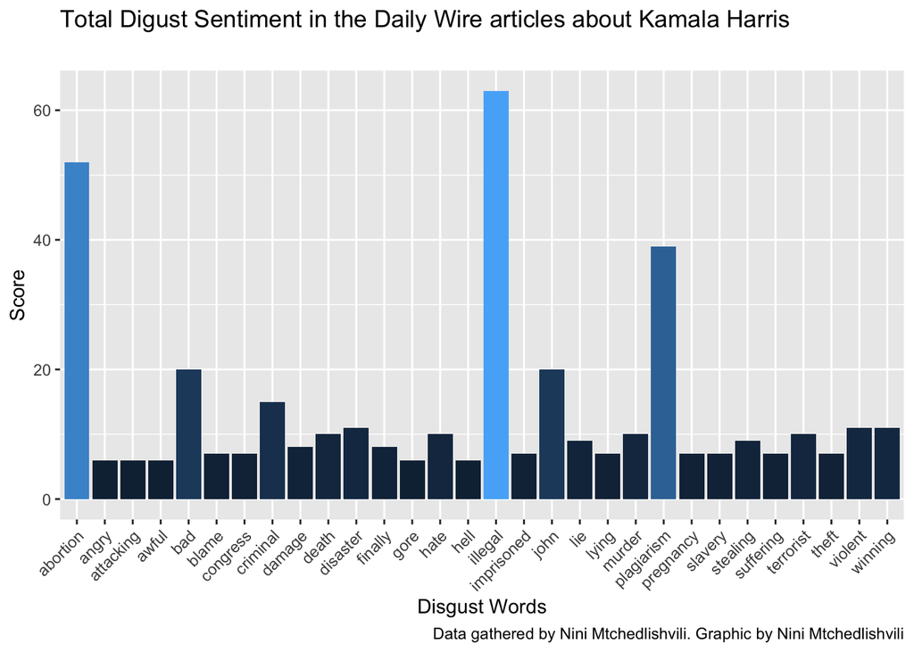

```r
kh_disgust_plot <- kh_t30_disgust %>%
  ggplot(aes(x = word, y = n, fill = n)) +
  geom_col(position = "dodge") +
  theme(legend.position = "none",
        axis.text.x = element_text(angle = 45, hjust = 1)) +
  labs(title = "Total Digust Sentiment in the Daily Wire articles about Kamala Harris",
       subtitle = " ",
       caption = "Data gathered by Nini Mtchedlishvili. Graphic by Nini Mtchedlishvili",
       y="Score",
       x="Disgust Words")

kh_disgust_plot
```

```r
dt_nrc_disgust <- dt_nrc_sentiments %>%
  filter(sentiment == "disgust")

dt_disgust <- dt_text_tokenized%>%
  inner_join(kh_nrc_disgust) %>%
  count(word, sort = TRUE)
dt_t30_disgust <- dt_disgust %>%
  head(30)

dt_t30_disgust
```

```
## # A tibble: 30 × 2
##    word         n
##    <chr>    <int>
##  1 abortion    53
##  2 illegal     35
##  3 john        33
##  4 garbage     31
##  5 bad         25
##  6 lose        19
##  7 winning     18
##  8 hate        17
##  9 lawsuit     17
## 10 tariff      13
## # ℹ 20 more rows
```

[figure not shown]

```r
dt_disgust_plot <- dt_t30_disgust %>%
  ggplot(aes(x = word, y = n, fill = n)) +
  geom_col(position = "dodge") +
  theme(legend.position = "none",
        axis.text.x = element_text(angle = 45, hjust = 1)) +
  labs(title = "Total Digust Sentiment in the Daily Wire articles about Donald Trump",
       subtitle = " ",
       caption = "Data gathered by Nini Mtchedlishvili. Graphic by Nini Mtchedlishvili",
       y="Score",
       x="Disgust Words")

kh_disgust_plot
```

## General Observations

Overall, the sentiment analysis underscores how word choice and framing in media coverage are strategically aligned to evoke specific emotions and reinforce targeted narratives, with noticeable differences in tone and focus between Harris and Trump.

## Conclusion

Data preparation process included:cleaning the text by removing punctuation, stopwords, numbers, and irrelevant or repetitive words; tokenizing the text into unigrams and bigrams to study individual words and two-word phrases; creating a word count column to understand the length of each article.

**Analytical Approach**

The analysis focused on two main aspects: textual patterns and sentiment analysis.

**Textual Patterns**: I identified the most frequent words and bigrams used in articles about each candidate. A word cloud was also created to provide a visual summary of the prominent terms. The analysis highlighted key themes, including frequent references to Donald Trump within articles about Kamala Harris, suggesting comparative framing.

Visualization To illustrate the findings, I used ggplot2 to create several visualizations: distribution histograms of word counts for articles about each candidate; bar plots of the top 30 bigrams to highlight commonly used phrases; sentiment bar charts for both candidates, showcasing the overall tone and specific emotional sentiments.